# R Notebook

Goal here is to get breakaway richness and evenness from all of the samples. Plot the like Emily Dougherty did her variables. (but With confidence intervals)

```r
library(breakaway)
library(flextable)
library(ftExtra)
source(here::here("RScripts", "InitialProcessing_3.R"))
```

```
here() starts at /home/jacob/Projects/ChesapeaakeMainstemAnalysis
* `` -> ...1

* `` -> ...1




extract_numeric() is deprecated: please use readr::parse_number() instead
```

```r
source(here::here("RLibraries", "ChesapeakePersonalLibrary.R"))
```

```r
otuTable <- nonSpikes %>% select(ID, ASV, reads) %>% pivot_wider(names_from = ASV, values_from = reads, id_cols = ID)
```

```r
otuMatrix <- otuTable %>% column_to_rownames(var = "ID") %>% as.matrix %>% t()
```

```r
otuPhyseq <- phyloseq::otu_table(otuMatrix, taxa_are_rows = FALSE)
```

```r
frequencytablelist <- build_frequency_count_tables(otuMatrix)
```

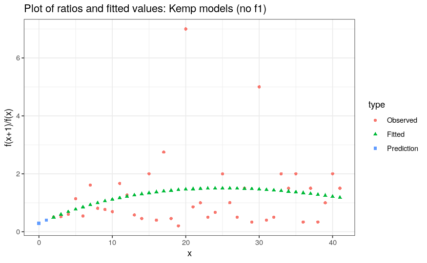

```r
plot(breakaway_nof1(frequencytablelist[[1]]))
```

```r
allBreak <- breakaway(otuPhyseq)
```

```r
richSummary <- summary(allBreak)
```

```r
richSummaryExpanded <- richSummary %>% left_join(sampleData, by = c("sample_names" = "ID"))
```

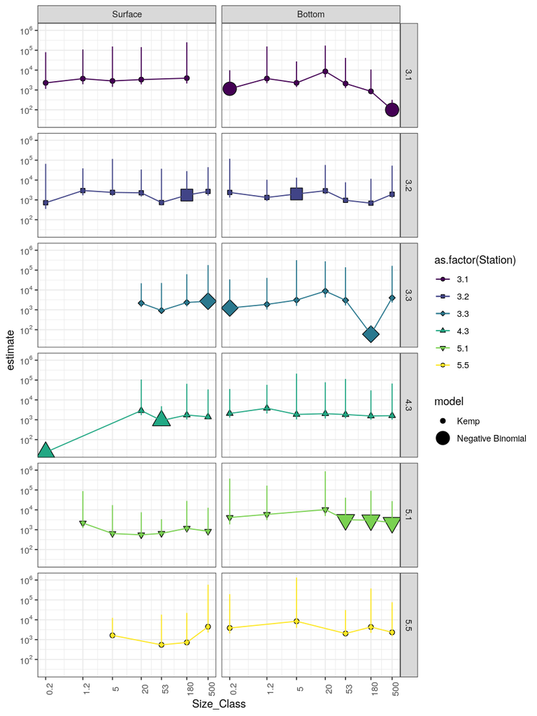

```r
richSummaryExpanded %>%
  arrange(Size_Class) %>%
  filter(Depth != "Oxy") %>%
  ggplot(
  aes(x = Size_Class, y = estimate,
      fill = as.factor(Station), shape = as.factor(Station))) +
  scale_y_log10nice() + scale_x_log10(breaks = my_sizes, labels = as.character(my_sizes)) +
  facet_grid(Station~Depth) +
  geom_point(aes(size = model)) +
  geom_segment(aes(x = Size_Class, xend = Size_Class, y = lower, yend = upper, color = as.factor(Station))) +
  geom_path(aes(color = as.factor(Station))) +
  scale_shape_manual(values = rep(21:25, 2)) +
  scale_fill_viridis_d() +
  scale_color_viridis_d() +
  theme_bw() +
  theme(axis.text.x = element_text(angle = 90))
```

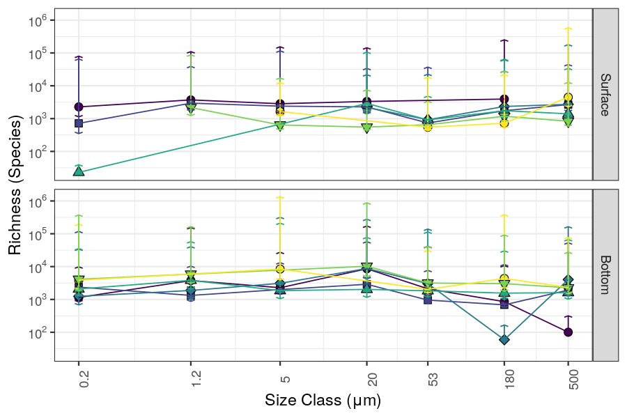

```r
richSummaryExpanded %>%
  arrange(Size_Class) %>%
  filter(Depth != "Oxy") %>%
  ggplot(
  aes(x = Size_Class, y = estimate,
      fill = as.factor(Station), shape = as.factor(Station))) +
  scale_y_log10nice() + scale_x_log10(breaks = my_sizes, labels = as.character(my_sizes)) +
  facet_grid(Depth~.) +
  geom_point(size = 3) +
  geom_segment(aes(x = Size_Class, xend = Size_Class, y = lower, yend = upper, color = as.factor(Station)), arrow = arrow(angle = 70, length = unit(0.05, "in"), ends = "both")) +
  geom_path(aes(color = as.factor(Station))) +
  labs(x = "Size Class (μm)", y = "Richness (Species)") +
  scale_shape_manual(values = rep(21:25, 2)) +
  scale_fill_viridis_d() +
  scale_color_viridis_d() +
  theme_bw(base_size = 14) +
  theme(axis.text.x = element_text(angle = 90), legend.position = "none")
```

There could be an alpha diversity effect (eg maximally high diversity at intermediate sizes) but its pretty subtle if it exists. There are generally 1k to 10k bugs per sample probably.

```r
myBet <- betta(
  formula = estimate ~ log(Size_Class) + I(log(Size_Class) ^2) + lat +  I(lat^2) + depth,
  ses = error,
  data = richSummaryExpanded %>% filter(depth != "Oxy")
)
```

```r
myBet$table
```

```
                         Estimates Standard Errors p-values
(Intercept)          7124599.39073     238.1841898    0.000
log(Size_Class)          115.12754      60.7376176    0.058
I(log(Size_Class)^2)     -50.49272      11.6218766    0.000
lat                  -370742.10322       6.1494273    0.000
I(lat^2)                4821.69098       0.1587166    0.000
depth                    150.02477      10.3193582    0.000
```

Apparently my R2 is like 15 percent so no wonder everything looks terrible

```r
myBet$table %>% as.data.frame() %>% rownames_to_column(var = "Parameter") %>%
  mutate(Estimates = format(Estimates, digits = 2, scientific = TRUE) %>%
           reformat_sci()
         ) %>%
  mutate(`Standard Errors` = format(`Standard Errors`, digits = 2, scientific = TRUE) %>%
           reformat_sci()
  ) %>%
  mutate(`p` = if_else(`p-values` < 0.001, "<0.001", paste(" ", as.character(`p-values`)))) %>%
  select(-`p-values`) %>%
  #mutate(Parameter = str_remove_all(Parameter, "I\\(|^\\(|\\)$")) %>% # why won't it remove left facing parentheses
  #mutate(Parameter = str_remove(Parameter, "\\)")) %>%
  mutate(Parameter = str_replace(Parameter, "^I?\\((.*)\\)", "\\1"),
         Parameter = str_replace(Parameter, "\\^2", "\\^2\\^"),
         Parameter = str_replace(Parameter, "depth", "Depth"),
         Parameter = str_replace(Parameter, "lat", "Latitude"),
         Parameter = str_replace(Parameter, "_", " ")# BOOKMARK!!
         ) %>%
  flextable() %>%
  colformat_md() %>%
  identity()
```

| Parameter | Estimates | Standard Errors | p |
| --- | --- | --- | --- |
| Intercept | 7.1 x 106 | 2.4 x 102 | <0.001 |
| log(Size Class) | 1.2 x 102 | 6.1 x 101 | 0.058 |
| log(Size Class)2 | -5.0 x 101 | 1.2 x 101 | <0.001 |
| Latitude | -3.7 x 105 | 6.1 x 100 | <0.001 |
| Latitude2 | 4.8 x 103 | 1.6 x 10-1 | <0.001 |
| Depth | 1.5 x 102 | 1.0 x 101 | <0.001 |

```r
breakLm <- lm(estimate ~ log(Size_Class) + I(log(Size_Class) ^2) + lat +  I(lat^2) + depth, data = richSummaryExpanded)
summary(breakLm)
```

```
Call:
lm(formula = estimate ~ log(Size_Class) + I(log(Size_Class)^2) +
    lat + I(lat^2) + depth, data = richSummaryExpanded)

Residuals:
    Min      1Q  Median      3Q     Max
-2974.5 -1191.2  -151.6   599.9  6768.1

Coefficients:
                       Estimate Std. Error t value Pr(>|t|)
(Intercept)          7124615.61 3339862.88   2.133   0.0365 *
log(Size_Class)          244.45     202.35   1.208   0.2312
I(log(Size_Class)^2)     -75.16      37.65  -1.996   0.0498 *
lat                  -370568.38  174035.93  -2.129   0.0368 *
I(lat^2)                4817.28    2265.61   2.126   0.0371 *
depth                    151.10      80.15   1.885   0.0636 .
---
Signif. codes:  0 ‘***’ 0.001 ‘**’ 0.01 ‘*’ 0.05 ‘.’ 0.1 ‘ ’ 1

Residual standard error: 1902 on 69 degrees of freedom
Multiple R-squared:  0.1414,    Adjusted R-squared:  0.0792
F-statistic: 2.273 on 5 and 69 DF,  p-value: 0.0567
```

Same overall pattern with less statistical significance

## To do

Calculate evenness by dividing shannon H by breakaway richness. (The values will be a lot smaller I think, but generally less affected by rarefaction because shannon is less affected (mostly driven by larger species)). I anticipate a more extreme curve.